# ds4pp Problem Set 4a: Tennessee STAR

Author

Spencer Lively

Published

February 14, 2024

Due to bcourses by the start of *class* (Thursday, Feb. 15 at 10:30am).

Often in data analysis work, pieces of information that are needed for an analysis may be spread across several different files. For example, consider the Tennessee STAR class-size experiment, which was a block-randomized trial where schools served as blocks and students were randomized to treatment conditions (large vs. small class sizes) within each school. If we found that the effect of being in a small class varied from school to school, we might wish to explore school-level characteristics that could explain such treatment effect variation.

## Setup and load data

The student-level test score records from this study are stored in one dataset, while school-level demographic information is stored in another.

```r
STAR_Student <- read_csv(file = "STAR_Grade3.csv")
STAR_School <- read_csv(file = "STAR_K-3_Schools.csv")
```

You might want to briefly explore each data set, just to get settled.

```r
head(STAR_Student)
```

```
# A tibble: 6 × 13
  stdntid gender race  birthmonth birthday birthyear cmpstype g1schid g1surban
    <dbl> <chr>  <chr> <chr>         <dbl>     <dbl> <chr>      <dbl> <chr>
1   10003 MALE   WHITE MAY              28      1980 REGULAR   257899 RURAL
2   10015 FEMALE BLACK AUGUST           25      1980 AIDE      205492 SUBURBAN
3   10022 FEMALE BLACK OCTOBER          27      1980 SMALL     244801 SUBURBAN
4   10026 FEMALE WHITE JANUARY          15      1979 SMALL     257905 URBAN
5   10032 MALE   BLACK FEBRUARY         19      1979 REGULAR   244776 INNER CITY
6   10033 MALE   WHITE MARCH             6      1980 <NA>      128076 SUBURBAN
# ℹ 4 more variables: g3treadss <dbl>, g3tmathss <dbl>, g3tlangss <dbl>,
#   g3tlistss <dbl>
```

```r
head(STAR_School)
```

```
# A tibble: 6 × 53
   schid schlurbn grdrange flaggk flagg1 flagg2 flagg3 gkenrmnt gkchapt1
   <dbl> <chr>    <chr>    <chr>  <chr>  <chr>  <chr>     <dbl> <chr>
1 112038 URBAN    K-5      Yes    Yes    Yes    Yes         330 YES
2 123056 RURAL    K-8      Yes    Yes    Yes    Yes         620 YES
3 128068 RURAL    K-8      Yes    No     No     No          540 YES
4 128076 SUBURBAN K-8      Yes    Yes    Yes    Yes         564 NO
5 128079 RURAL    K-5      Yes    Yes    Yes    Yes         471 YES
6 130085 SUBURBAN K-5      Yes    Yes    Yes    Yes         521 YES
# ℹ 44 more variables: gkfrlnch <dbl>, gkbused <dbl>, gknatvam <dbl>,
#   gkasian <dbl>, gkblack <dbl>, gkhspanc <dbl>, gkwhite <dbl>,
#   gkothrac <dbl>, g1enrmnt <dbl>, g1avgdat <dbl>, g1avgdmb <dbl>,
#   g1chapt1 <chr>, g1frlnch <dbl>, g1bused <dbl>, g1natvam <dbl>,
#   g1asian <dbl>, g1black <dbl>, g1hspanc <dbl>, g1white <dbl>,
#   g1othrac <dbl>, g2enrmnt <dbl>, g2avgdat <dbl>, g2avgdmb <dbl>,
#   g2chapt1 <chr>, g2frlnch <dbl>, g2bused <dbl>, g2natvam <dbl>, …
```

## Aggregate data to the school level

We’ll start by aggregating data to the school level. Before we do that, we’re going to make things *slightly* easier for you by dropping missing values for `g3tmathss`. (We could incorporate this later on, but it makes things a bit messier.)

```r
STAR_Student |> ## what happens if you don't drop missing values? Find out!!
  drop_na(g3tmathss) -> STAR_Student
```

Now, create a new dataset named school_g3_averages at the school level that includes the average 3rd grade math score overall (`g3tmathss`). (*Hint:* `g1schid` is the unique identifier for school.)

```r
school_g3_averages <- STAR_Student %>%
  group_by(g1schid) %>%
  summarize(avg_g3_math_score = mean(g3tmathss, na.rm = TRUE))
```

## Merge

Now merge the average, school-level third grade math score onto `STAR_School`. Save the new dataframe as `school_merged`. (*Hint:* What are the unique identifiers/“keys” called in each data set? Are they the same variable name?)

```r
school_merged <- merge(STAR_School, school_g3_averages, by.x = "schid", by.y = "g1schid")
```

Merges work best if the key that you merge on is unique—meaning that there is a unique key for each row of the dataframe. Let’s check that both our original left side of the merge was unique by the key and that the resulting merged dataframe has the same number of rows and the same uniqueness.

```r
### to test uniqueness, compare the number of rows in the dataframe to the number of distinct values in the key column
nrow(STAR_School)
```

```
[1] 80
```

```r
STAR_School |>
  select(schid) |>
  n_distinct()
```

```
[1] 80
```

```r
### this confirms that schid is a unique key for STAR_School

### is the new merged data the same number of rows as the original dataframe?
nrow(school_merged)
```

```
[1] 64
```

```r
### No. It has 64 rows instead of 80.
```

Assess the quality of the merge. Are you missing any values of the average third grade math score? How many? Why are you missing them? (*Hint:* You probably *should* be missing some values…)

```r
missing_values <- sum(is.na(school_merged$avg_g3_math_score))
missing_values
```

```
[1] 0
```

```r
### I'm not missing any values? I'm not sure why it says 'should'... but that would be that case if there were any rows in the 'STAR_School' dataset that do not have corresponding rows with the same unique ID variable in the 'school_g3_averages' dataset.
```

## Explore the data

### What is the relationship between average math score and school urbanicity (`schlurbn`)?

First plot boxplots of the grade three math scores by urbanicity. (*Hint:* You should remove rows with missing values in the variables you are trying to plot. The plot will probably still work but you’ll get a bunch of warnings and it’s best practice to do it yourself)

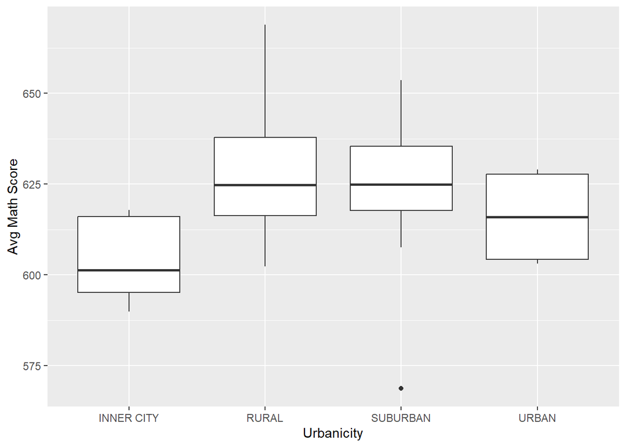

```r
library(ggplot2)
ggplot(data = school_merged, aes(x = as.factor(schlurbn), y = avg_g3_math_score)) +
  geom_boxplot() +
  labs(x = "Urbanicity", y = "Avg Math Score")
```

Now plot the density of grade three math scores by urbanicity.

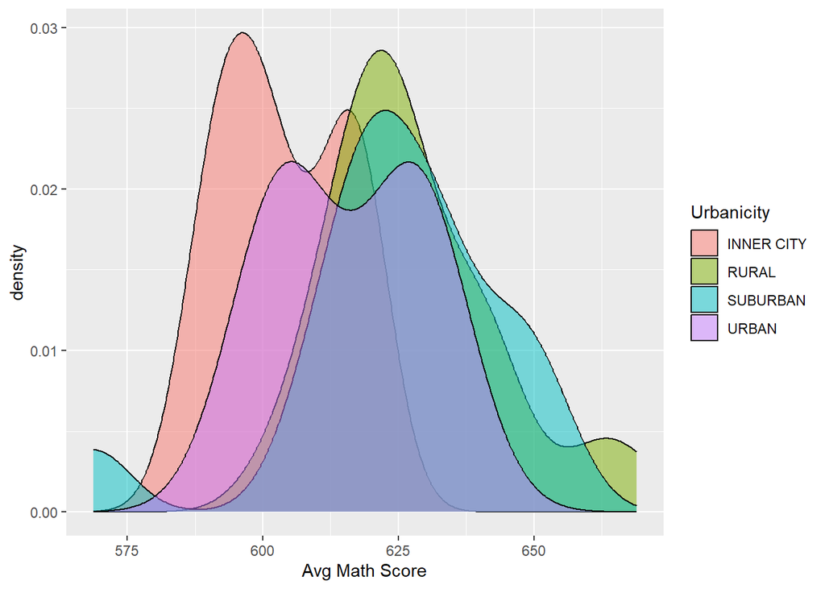

```r
ggplot(data = school_merged, aes(x = avg_g3_math_score, fill = as.factor(schlurbn))) +
  geom_density(alpha = 0.5) +
  labs(x = "Avg Math Score", fill = "Urbanicity")
```

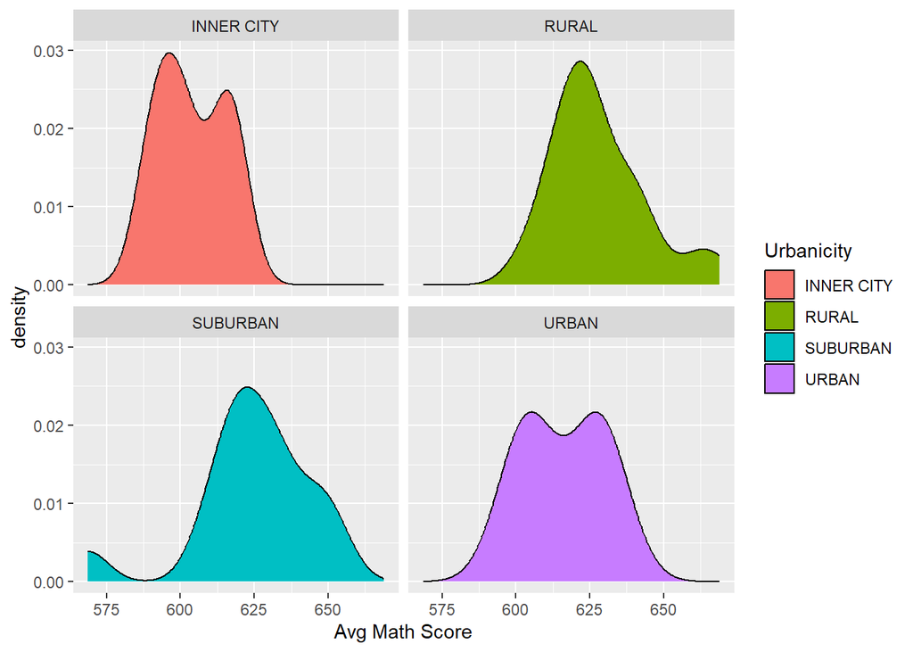

```r
ggplot(data = school_merged, aes(x = avg_g3_math_score, fill = as.factor(schlurbn))) +
  geom_density() +
  labs(x = "Avg Math Score", fill = "Urbanicity") +
  facet_wrap(~ as.factor(schlurbn), ncol = 2)
```

What does the density plot show you that the boxplot doesn’t? What are the pros and cons of each plot?

Density plots show the shape and spread, which makes them suitable for continuous data and for showing more detailed information. However, boxplots can instead provide a concise summary of key statistics such as the median, quartiles, and outliers, which makes for easier interpretation but lacks in detail.

### What is the relationship between average math score and percent free and reduced price lunch status (`g3frlnch`)?

Make a scatterplot to explore the relationship.

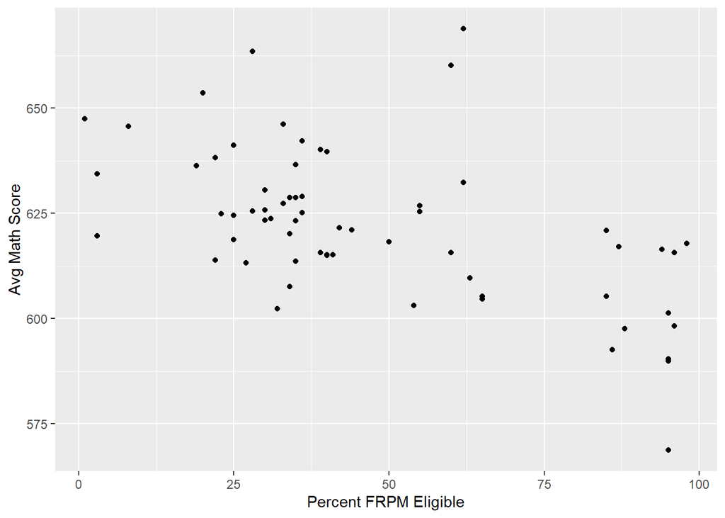

```r
ggplot(data = school_merged, aes(x = g3frlnch, y = avg_g3_math_score)) +
  geom_point() +
  labs(x = "Percent FRPM Eligible", y = "Avg Math Score")
```

A simple scatterplot doesn’t always tell you the full story. What changes can you make to the scatterplot to explore further dynamics in the relationship between average math score and percent free and reduced price lunch status?

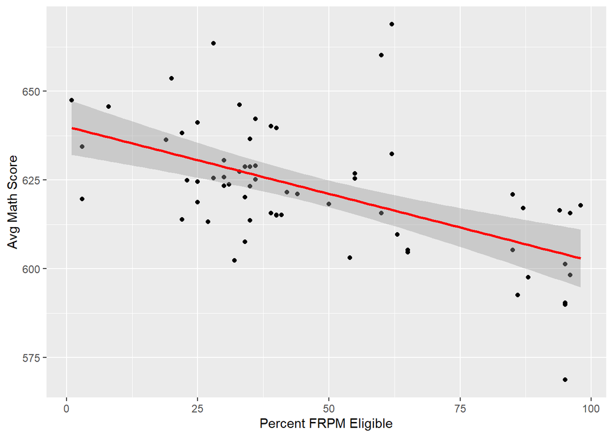

```r
ggplot(data = school_merged, aes(x = g3frlnch, y = avg_g3_math_score)) +
  geom_point() +
  geom_smooth(method = "lm", se = TRUE, color = "red", level=.95) +
  labs(x = "Percent FRPM Eligible", y = "Avg Math Score")
```

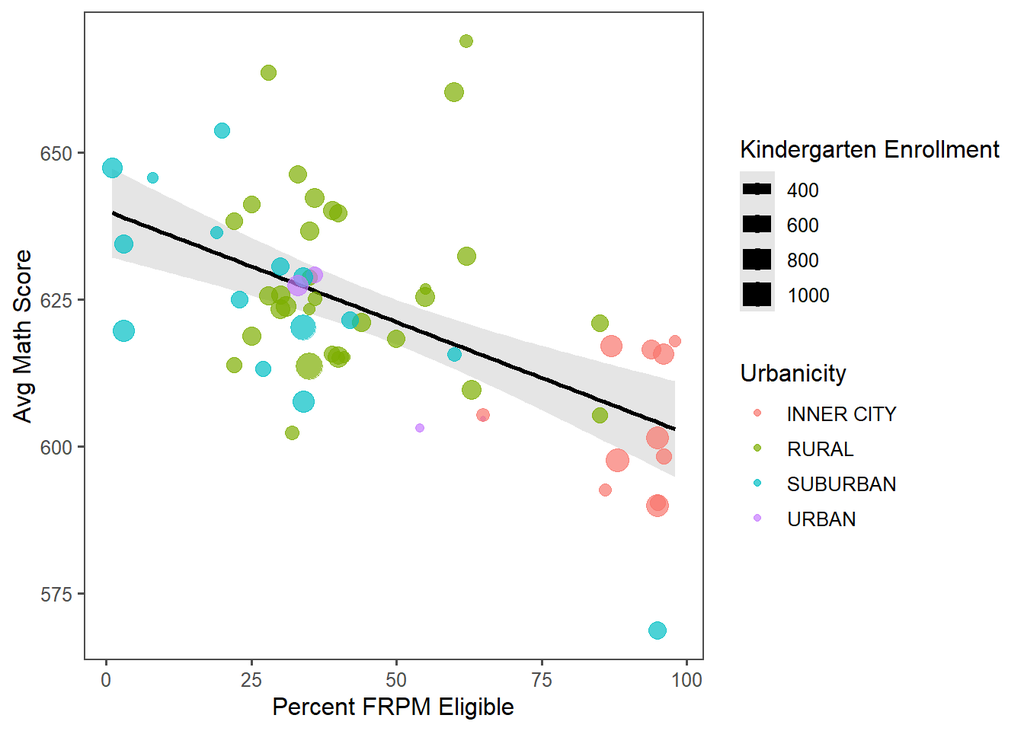

```r
ggplot(data = school_merged, aes(x = g3frlnch, y = avg_g3_math_score, size = gkenrmnt,color=as.factor(schlurbn))) +
  geom_smooth(method = "lm", se = TRUE, color = "black", level=.95, alpha=.25) +
  geom_point(alpha = 0.7) +
  labs(x = "Percent FRPM Eligible", y = "Avg Math Score", size = "Kindergarten Enrollment", color = "Urbanicity") + ggthemes::theme_few()
```